# Face Generation

### MNIST Run 3: decrease learning rate

Generator

- layer 1: 4x4x512 with LRELU
- layer 2: 7x7x256 with LRELU
- layer 3: 14x14x128 with LRELU
- layer 4: 28x28xOutput_Channel with TANH

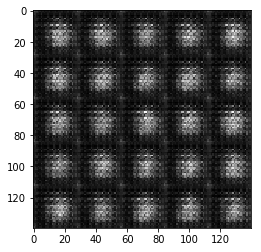

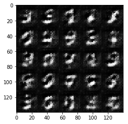

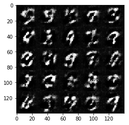

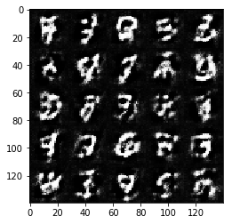

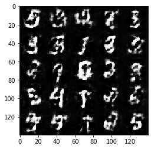

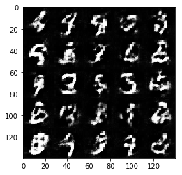

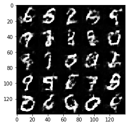

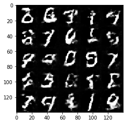

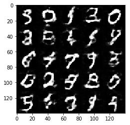

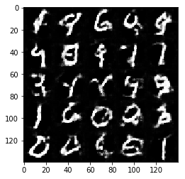

```python
batch_size = 128
z_dim = 100
learning_rate = 0.0001
beta1 = 0.5

d_losses = []
g_losses = []

"""
DON'T MODIFY ANYTHING IN THIS CELL THAT IS BELOW THIS LINE
"""
epochs = 2

mnist_dataset = helper.Dataset('mnist', glob(os.path.join(data_dir, 'mnist/*.jpg')))
with tf.Graph().as_default():
    # jcc: added lists for plotting discriminator and generator losses
    d_losses, g_losses = train(epochs, batch_size, z_dim, learning_rate, beta1, mnist_dataset.get_batches,
          mnist_dataset.shape, mnist_dataset.image_mode)
```

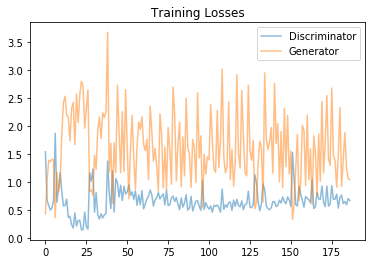

```python
plot_losses(d_losses, g_losses)
```

### MNIST Run 4

The Generator defined in Run 1 seems to give the best results so far. We return to it and experiment with some of the other hyperparameters.

Generator shape:

- layer 1: 4x4x1024 with LRELU activation
- layer 2: 7x7x512 with LRELU
- layer 3: 14x14x256 with LRELU
- layer 4: 28x28xOutput_Channel with TANH

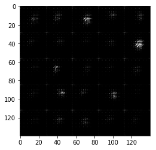

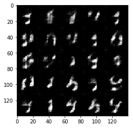

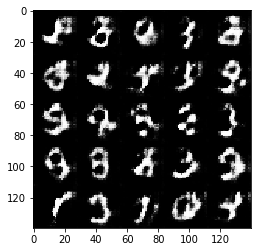

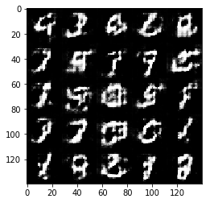

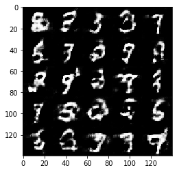

```python
batch_size = 256
z_dim = 100
learning_rate = 0.0002
beta1 = 0.5

d_losses = []
g_losses = []

"""
DON'T MODIFY ANYTHING IN THIS CELL THAT IS BELOW THIS LINE
"""
epochs = 2

mnist_dataset = helper.Dataset('mnist', glob(os.path.join(data_dir, 'mnist/*.jpg')))
with tf.Graph().as_default():
    # jcc: added lists for plotting discriminator and generator losses
    d_losses, g_losses = train(epochs, batch_size, z_dim, learning_rate, beta1, mnist_dataset.get_batches,
          mnist_dataset.shape, mnist_dataset.image_mode)
```

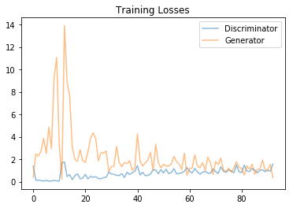

```python
plot_losses(d_losses, g_losses)
```

### Results:

Use parameters from MNIST run no. 1 as the starting point for CelebA dataset.

### CelebA

Run your GANs on CelebA. It will take around 20 minutes on the average GPU to run one epoch. You can run the whole epoch or stop when it starts to generate realistic faces.

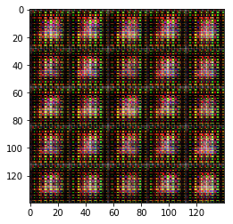

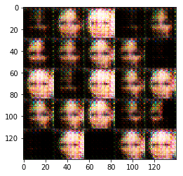

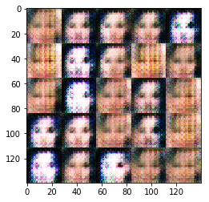

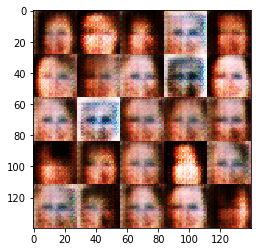

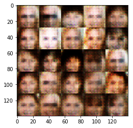

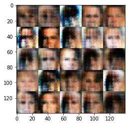

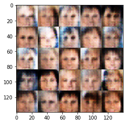

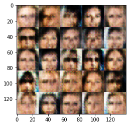

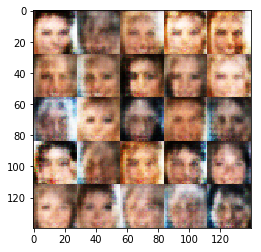

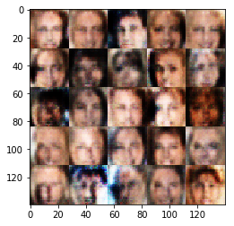

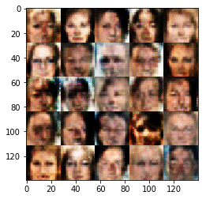

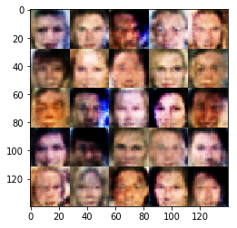

[4 more figures not shown]

```python
batch_size = 128
z_dim = 100
learning_rate = 0.0002
beta1 = 0.5

d_losses = []
g_losses = []


"""
DON'T MODIFY ANYTHING IN THIS CELL THAT IS BELOW THIS LINE
"""
epochs = 1

celeba_dataset = helper.Dataset('celeba', glob(os.path.join(data_dir, 'img_align_celeba/*.jpg')))
with tf.Graph().as_default():
    # jcc: added lists for plotting discriminator and generator losses
    d_losses, g_losses = train(epochs, batch_size, z_dim, learning_rate, beta1, celeba_dataset.get_batches,
          celeba_dataset.shape, celeba_dataset.image_mode)
```

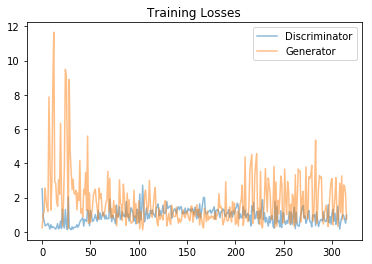

```python
plot_losses(d_losses, g_losses)
```

### Submitting This Project

When submitting this project, make sure to run all the cells before saving the notebook. Save the notebook file as "dlnd_face_generation.ipynb" and save it as a HTML file under "File" -> "Download as". Include the "helper.py" and "problem_unittests.py" files in your submission.